# barbell lift performance analysis & prediction based on accelerometer data

Johannes

27 7 2020

## 1. getting and cleaning data

```r
wbdat <- read.csv("https://d396qusza40orc.cloudfront.net/predmachlearn/pml-training.csv")
wbval <- read.csv("https://d396qusza40orc.cloudfront.net/predmachlearn/pml-testing.csv")
```

We can clean the data by taking converting the class variable to a factor and removing the NA data which is in the columns of the variance.

```r
wbdat$classe <- as.factor(wbdat$classe)
wbdat$user_name <- as.factor(wbdat$user_name)
wbval$user_name <- as.factor(wbval$user_name)

ixAcc <- grep("acc", colnames(wbdat))
wbdatAc <- cbind(wbdat[,ixAcc], user_name = wbdat$user_name, classe = wbdat$classe)
wbvalAc <- cbind(wbval[,ixAcc], user_name = wbval$user_name, problem_id = wbval$problem_id)
ixvar <- grep("var", colnames(wbdatAc))
wbdatAc <- wbdatAc[,-ixvar]
wbvalAc <- wbvalAc[,-ixvar]
summary(wbdatAc)
```

```
##  total_accel_belt  accel_belt_x       accel_belt_y     accel_belt_z
##  Min.   : 0.00    Min.   :-120.000   Min.   :-69.00   Min.   :-275.00
##  1st Qu.: 3.00    1st Qu.: -21.000   1st Qu.:  3.00   1st Qu.:-162.00
##  Median :17.00    Median : -15.000   Median : 35.00   Median :-152.00
##  Mean   :11.31    Mean   :  -5.595   Mean   : 30.15   Mean   : -72.59
##  3rd Qu.:18.00    3rd Qu.:  -5.000   3rd Qu.: 61.00   3rd Qu.:  27.00
##  Max.   :29.00    Max.   :  85.000   Max.   :164.00   Max.   : 105.00
##  total_accel_arm  accel_arm_x       accel_arm_y      accel_arm_z
##  Min.   : 1.00   Min.   :-404.00   Min.   :-318.0   Min.   :-636.00
##  1st Qu.:17.00   1st Qu.:-242.00   1st Qu.: -54.0   1st Qu.:-143.00
##  Median :27.00   Median : -44.00   Median :  14.0   Median : -47.00
##  Mean   :25.51   Mean   : -60.24   Mean   :  32.6   Mean   : -71.25
##  3rd Qu.:33.00   3rd Qu.:  84.00   3rd Qu.: 139.0   3rd Qu.:  23.00
##  Max.   :66.00   Max.   : 437.00   Max.   : 308.0   Max.   : 292.00
##  total_accel_dumbbell accel_dumbbell_x  accel_dumbbell_y  accel_dumbbell_z
##  Min.   : 0.00        Min.   :-419.00   Min.   :-189.00   Min.   :-334.00
##  1st Qu.: 4.00        1st Qu.: -50.00   1st Qu.:  -8.00   1st Qu.:-142.00
##  Median :10.00        Median :  -8.00   Median :  41.50   Median :  -1.00
##  Mean   :13.72        Mean   : -28.62   Mean   :  52.63   Mean   : -38.32
##  3rd Qu.:19.00        3rd Qu.:  11.00   3rd Qu.: 111.00   3rd Qu.:  38.00
##  Max.   :58.00        Max.   : 235.00   Max.   : 315.00   Max.   : 318.00
##  total_accel_forearm accel_forearm_x   accel_forearm_y  accel_forearm_z
##  Min.   :  0.00      Min.   :-498.00   Min.   :-632.0   Min.   :-446.00
##  1st Qu.: 29.00      1st Qu.:-178.00   1st Qu.:  57.0   1st Qu.:-182.00
##  Median : 36.00      Median : -57.00   Median : 201.0   Median : -39.00
##  Mean   : 34.72      Mean   : -61.65   Mean   : 163.7   Mean   : -55.29
##  3rd Qu.: 41.00      3rd Qu.:  76.00   3rd Qu.: 312.0   3rd Qu.:  26.00
##  Max.   :108.00      Max.   : 477.00   Max.   : 923.0   Max.   : 291.00
##     user_name    classe
##  adelmo  :3892   A:5580
##  carlitos:3112   B:3797
##  charles :3536   C:3422
##  eurico  :3070   D:3216
##  jeremy  :3402   E:3607
##  pedro   :2610
```

## 2. exploratory data analysis

```r
library(caret)
```

```r
library(ggplot2)
nearZeroVar(wbdatAc, saveMetrics = TRUE)
```

```
##                      freqRatio percentUnique zeroVar   nzv
## total_accel_belt      1.063160    0.14779329   FALSE FALSE
## accel_belt_x          1.055412    0.83579655   FALSE FALSE
## accel_belt_y          1.113725    0.72877383   FALSE FALSE
## accel_belt_z          1.078767    1.52379982   FALSE FALSE
## total_accel_arm       1.024526    0.33635715   FALSE FALSE
## accel_arm_x           1.017341    3.95984099   FALSE FALSE
## accel_arm_y           1.140187    2.73672409   FALSE FALSE
## accel_arm_z           1.128000    4.03628580   FALSE FALSE
## total_accel_dumbbell  1.072634    0.21914178   FALSE FALSE
## accel_dumbbell_x      1.018018    2.16593619   FALSE FALSE
## accel_dumbbell_y      1.053061    2.37488533   FALSE FALSE
## accel_dumbbell_z      1.133333    2.08949139   FALSE FALSE
## total_accel_forearm   1.128928    0.35674243   FALSE FALSE
## accel_forearm_x       1.126437    4.04647844   FALSE FALSE
## accel_forearm_y       1.059406    5.11160942   FALSE FALSE
## accel_forearm_z       1.006250    2.95586586   FALSE FALSE
## user_name             1.100679    0.03057792   FALSE FALSE
## classe                1.469581    0.02548160   FALSE FALSE
```

Since the unique percentage of the total_accel… values is below the value of the single accelerometer data we start analyzing based on those predictors.

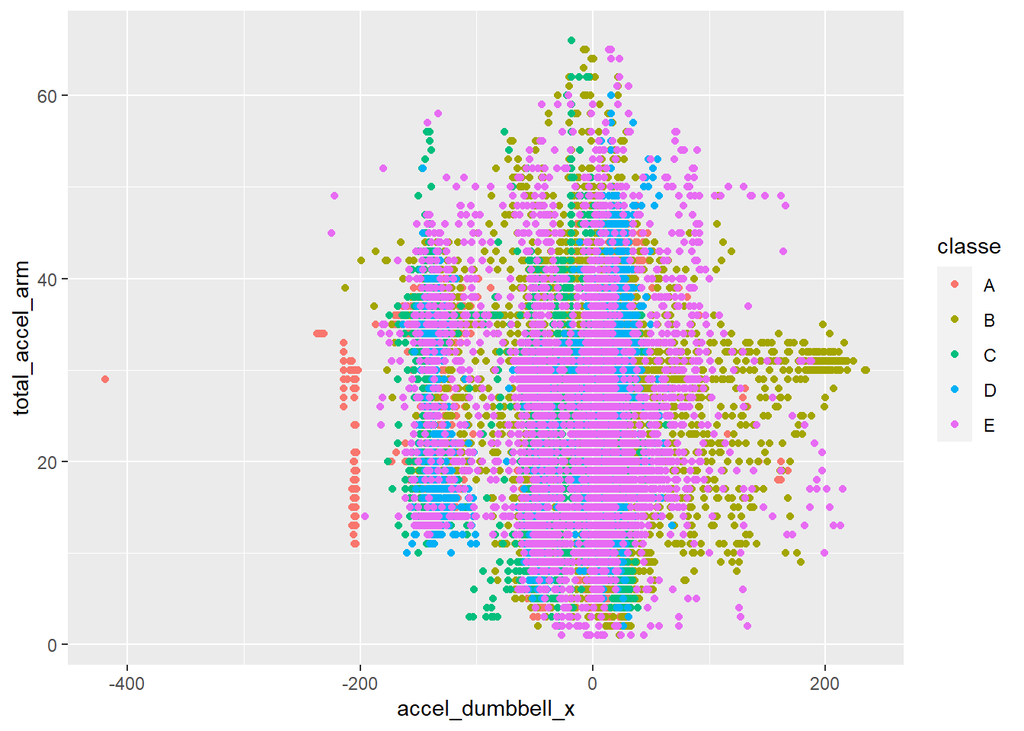

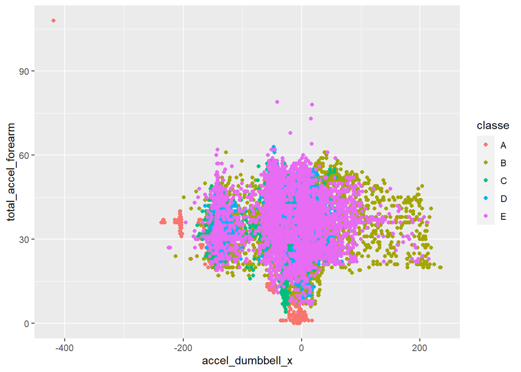

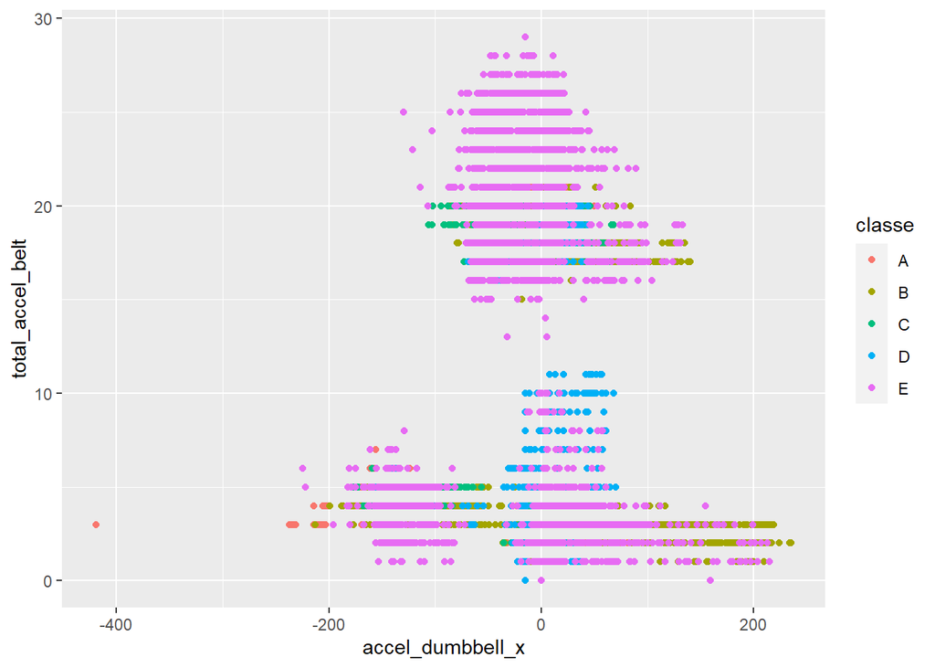

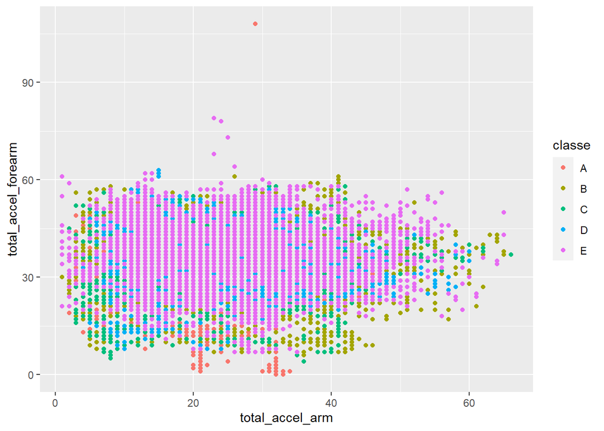

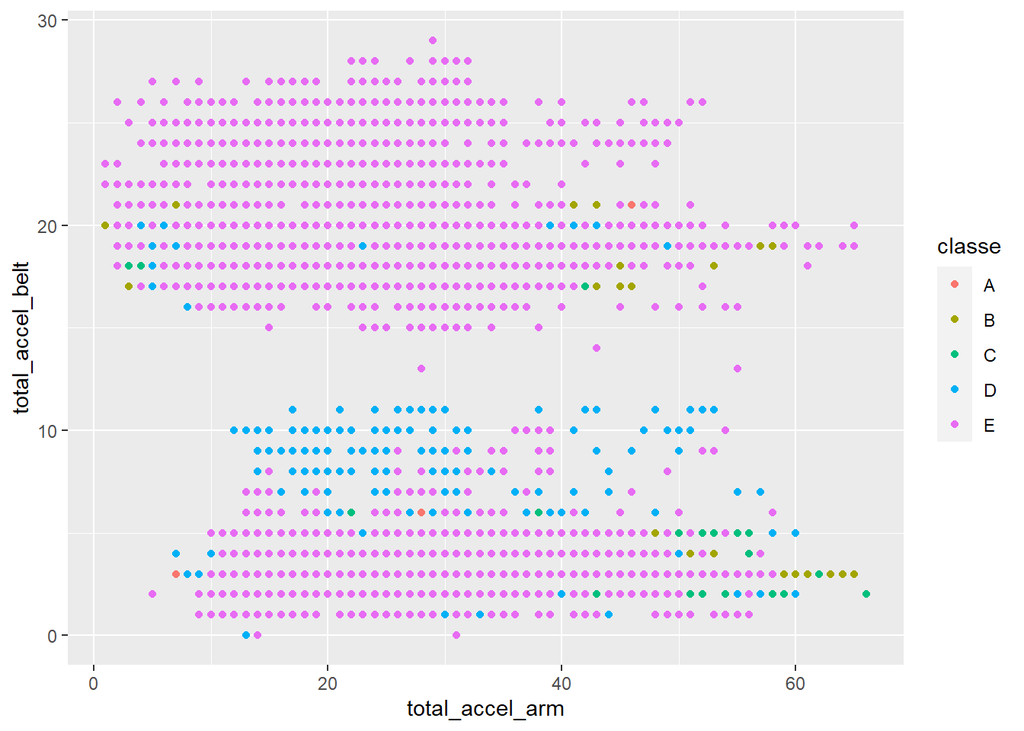

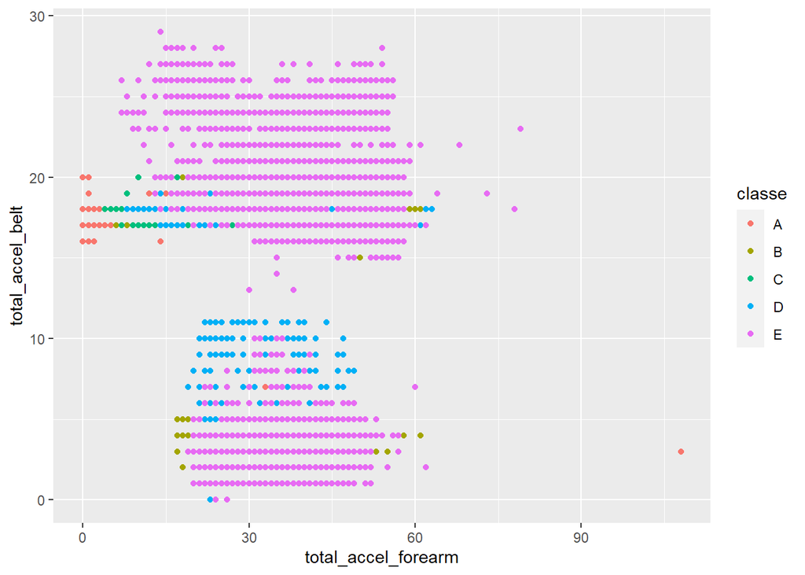

As result we can observe clear patterns that we try to exploit in the next steps.

## 3. predictor- and model selection

We will split the data into a training and a test set

```r
inTrain <- createDataPartition(y=wbdatAc$classe, p = 0.7, list = FALSE)
wbtrain <- wbdatAc[inTrain, ]
wbtest <- wbdatAc[-inTrain, ]
```

Now we start applying the models comparing the accuracy of each model 1. Linear discriminant analysis

```r
control <- trainControl(method="cv", number=3)
m0 <- train(classe~., data = wbtrain, method = "lda", trainControl = control)
pred1 <- predict(m0, wbtest)
confusionMatrix(pred1, wbtest$classe)$overall[1]
```

```
##  Accuracy
## 0.5539507
```

2. K nearest neighbour

```r
m01 <- train(classe~., data=wbtrain, method = "knn")
pred01 <- predict(m01, wbtest)
confusionMatrix(pred01, wbtest$classe)$overall[1]
```

```
## Accuracy
## 0.857774
```

3. Random Forest

```r
library(randomForest)
m3 <- randomForest(classe~., data=wbtrain)
pred3 <- predict(m3, wbtest)
confusionMatrix(pred3, wbtest$classe)$overall[1]
```

```
## Accuracy
## 0.942226
```

The complete confusion matrix is:

```r
confusionMatrix(pred3, wbtest$classe)
```

```
## Confusion Matrix and Statistics
##
##           Reference
## Prediction    A    B    C    D    E
##          A 1595   38   16   27    1
##          B   21 1051   37    4   15
##          C   32   28  958   35    5
##          D   26   11   13  894   14
##          E    0   11    2    4 1047
##
## Overall Statistics
##
##                Accuracy : 0.9422
##                  95% CI : (0.936, 0.9481)
##     No Information Rate : 0.2845
##     P-Value [Acc > NIR] : < 2.2e-16
##
##                   Kappa : 0.9269
##
##  Mcnemar's Test P-Value : 0.0002422
##
## Statistics by Class:
##
##                      Class: A Class: B Class: C Class: D Class: E
## Sensitivity            0.9528   0.9227   0.9337   0.9274   0.9677
## Specificity            0.9805   0.9838   0.9794   0.9870   0.9965
## Pos Pred Value         0.9511   0.9317   0.9055   0.9332   0.9840
## Neg Pred Value         0.9812   0.9815   0.9859   0.9858   0.9927
## Prevalence             0.2845   0.1935   0.1743   0.1638   0.1839
## Detection Rate         0.2710   0.1786   0.1628   0.1519   0.1779
## Detection Prevalence   0.2850   0.1917   0.1798   0.1628   0.1808
## Balanced Accuracy      0.9667   0.9533   0.9566   0.9572   0.9821
```

We will select the random forest model for the further predictions.

## 4. Apply to validation/“Quizz” set

```r
predval <- predict(m3, wbvalAc)
data.frame(wbvalAc$problem_id, predval)
```

```
##    wbvalAc.problem_id predval
## 1                   1       B
## 2                   2       A
## 3                   3       C
## 4                   4       A
## 5                   5       A
## 6                   6       E
## 7                   7       D
## 8                   8       B
## 9                   9       A
## 10                 10       A
## 11                 11       B
## 12                 12       C
## 13                 13       B
## 14                 14       A
## 15                 15       E
## 16                 16       E
## 17                 17       A
## 18                 18       B
## 19                 19       B
## 20                 20       B
```